# Lab 3

Aleah Querns

2/11/2022

# Setup

```r
library(gapminder)
library(tidyverse)
library(datasets)
library(viridis)
library(gridExtra)
library(MuMIn)

knitr::opts_knit$set(root.dir = '~/Documents/K-State Year 2/GEOG728/GEOG728_GIT')
```

## The Dataset

```r
food <- read.csv("DATA/FoodAtlas.csv")

foodkey<-read.csv("DATA/FoodAtlas_key.csv")
```

### 1. Reduce this dataset down to the first 24 and last 12 variables in the original dataset

```r
colnames(food)
```

```
##   [1] "CensusTract"          "State"                "County"
##   [4] "Urban"                "POP2010"              "OHU2010"
##   [7] "GroupQuartersFlag"    "NUMGQTRS"             "PCTGQTRS"
##  [10] "LILATracts_1And10"    "LILATracts_halfAnd10" "LILATracts_1And20"
##  [13] "LILATracts_Vehicle"   "HUNVFlag"             "LowIncomeTracts"
##  [16] "PovertyRate"          "MedianFamilyIncome"   "LA1and10"
##  [19] "LAhalfand10"          "LA1and20"             "LATracts_half"
##  [22] "LATracts1"            "LATracts10"           "LATracts20"
##  [25] "LATractsVehicle_20"   "LAPOP1_10"            "LAPOP05_10"
##  [28] "LAPOP1_20"            "LALOWI1_10"           "LALOWI05_10"
##  [31] "LALOWI1_20"           "lapophalf"            "lapophalfshare"
##  [34] "lalowihalf"           "lalowihalfshare"      "lakidshalf"
##  [37] "lakidshalfshare"      "laseniorshalf"        "laseniorshalfshare"
##  [40] "lawhitehalf"          "lawhitehalfshare"     "lablackhalf"
##  [43] "lablackhalfshare"     "laasianhalf"          "laasianhalfshare"
```

[output cut: 34 more lines]

```r
foodr <- food %>%
  select(CensusTract:LATracts20, TractLOWI:TractSNAP)

foodr_key <- foodkey %>%
  slice(1:24, 136:147)
```

### 2. Examine this reduced dataset and describe what type of data you’re working with. What is the data structure? What types of variables? Etc…

```r
str(foodr)
```

```
## 'data.frame':    72864 obs. of  36 variables:
##  $ CensusTract         : num  1e+09 1e+09 1e+09 1e+09 1e+09 ...
##  $ State               : chr  "Alabama" "Alabama" "Alabama" "Alabama" ...
##  $ County              : chr  "Autauga" "Autauga" "Autauga" "Autauga" ...
##  $ Urban               : int  1 1 1 1 1 1 1 0 0 0 ...
##  $ POP2010             : int  1912 2170 3373 4386 10766 3668 2891 3081 10435 5675 ...
##  $ OHU2010             : int  693 743 1256 1722 4082 1311 1188 1074 3694 2067 ...
##  $ GroupQuartersFlag   : int  0 0 0 0 0 0 0 0 0 0 ...
##  $ NUMGQTRS            : int  0 181 0 0 181 0 36 0 0 14 ...
##  $ PCTGQTRS            : num  0 0.0834 0 0 0.0168 ...
##  $ LILATracts_1And10   : int  0 0 0 0 0 0 1 0 0 0 ...
##  $ LILATracts_halfAnd10: int  0 0 0 0 0 0 1 0 0 0 ...
##  $ LILATracts_1And20   : int  0 0 0 0 0 0 1 0 0 0 ...
##  $ LILATracts_Vehicle  : int  0 0 0 0 0 0 1 0 0 0 ...
##  $ HUNVFlag            : int  0 0 0 0 1 0 1 1 0 0 ...
```

[output cut: 22 more lines]

```r
colnames(foodr)
```

```
##  [1] "CensusTract"          "State"                "County"
##  [4] "Urban"                "POP2010"              "OHU2010"
##  [7] "GroupQuartersFlag"    "NUMGQTRS"             "PCTGQTRS"
## [10] "LILATracts_1And10"    "LILATracts_halfAnd10" "LILATracts_1And20"
## [13] "LILATracts_Vehicle"   "HUNVFlag"             "LowIncomeTracts"
## [16] "PovertyRate"          "MedianFamilyIncome"   "LA1and10"
## [19] "LAhalfand10"          "LA1and20"             "LATracts_half"
## [22] "LATracts1"            "LATracts10"           "LATracts20"
## [25] "TractLOWI"            "TractKids"            "TractSeniors"
## [28] "TractWhite"           "TractBlack"           "TractAsian"
## [31] "TractNHOPI"           "TractAIAN"            "TractOMultir"
## [34] "TractHispanic"        "TractHUNV"            "TractSNAP"
```

```r
dim(foodr)
```

```
## [1] 72864    36
```

```r
head(foodr, 15)
```

```
##    CensusTract   State  County Urban POP2010 OHU2010 GroupQuartersFlag NUMGQTRS
## 1   1001020100 Alabama Autauga     1    1912     693                 0        0
## 2   1001020200 Alabama Autauga     1    2170     743                 0      181
## 3   1001020300 Alabama Autauga     1    3373    1256                 0        0
## 4   1001020400 Alabama Autauga     1    4386    1722                 0        0
## 5   1001020500 Alabama Autauga     1   10766    4082                 0      181
## 6   1001020600 Alabama Autauga     1    3668    1311                 0        0
## 7   1001020700 Alabama Autauga     1    2891    1188                 0       36
## 8   1001020801 Alabama Autauga     0    3081    1074                 0        0
## 9   1001020802 Alabama Autauga     0   10435    3694                 0        0
## 10  1001020900 Alabama Autauga     0    5675    2067                 0       14
## 11  1001021000 Alabama Autauga     0    2894    1085                 0       10
## 12  1001021100 Alabama Autauga     0    3320    1306                 0       33
## 13  1003010100 Alabama Baldwin     0    3804    1510                 0       31
## 14  1003010200 Alabama Baldwin     0    2902    1111                 0        6
```

[output cut: 81 more lines]

```r
tail(foodr, 15)
```

```
##       CensusTract   State     County Urban POP2010 OHU2010 GroupQuartersFlag
## 72850 56037971100 Wyoming Sweetwater     1    3321    1377                 0
## 72851 56037971200 Wyoming Sweetwater     1    2524    1053                 0
## 72852 56037971600 Wyoming Sweetwater     0    2092     857                 0
## 72853 56039967600 Wyoming      Teton     0    4600    2022                 0
## 72854 56039967701 Wyoming      Teton     1    2271     975                 0
## 72855 56039967702 Wyoming      Teton     0    6411    2729                 0
## 72856 56039967800 Wyoming      Teton     0    8012    3247                 0
## 72857 56041975200 Wyoming      Uinta     0    6505    2340                 0
## 72858 56041975300 Wyoming      Uinta     0    7761    2696                 0
## 72859 56041975400 Wyoming      Uinta     0    6852    2632                 0
## 72860 56043000200 Wyoming   Washakie     0    3326    1317                 0
## 72861 56043000301 Wyoming   Washakie     1    2665    1154                 0
## 72862 56043000302 Wyoming   Washakie     1    2542    1021                 0
## 72863 56045951100 Wyoming     Weston     0    3314    1322                 0
```

[output cut: 97 more lines]

```r
sum(rowSums(is.na(foodr))>0)
```

```
## [1] 0
```

It appears that this dataset provides census data specific to certain state/counties. POP2010 and OHU2010 give total population and housing numbers respectively, GroupQuartersFlag:LATracts20 provide relevant descriptive variables, and TractLOWI:TractSNAP provide population counts specific to certain demographics.

The data shows 72864 rows and 36 columns, where most columns are numeric/integer format except for State and County, which are characters

Luckily, the dataset has no NAs.

### 3: Now make a new data object for the state of Kansas that includes just County, POP2010, LAhalfand10, MedianFamilyIncome,TractSNAP, and TractKids variables.

```r
foodk <- foodr %>%
  filter(State== "Kansas")%>%
  select(County, POP2010, LAhalfand10, MedianFamilyIncome, TractSNAP, TractKids)
```

### 4: Create a plot to illustrate the differences in MedianFamilyIncome across counties in Kansas. Are there significant differences across counties? Which counties have the greatest variation in income?

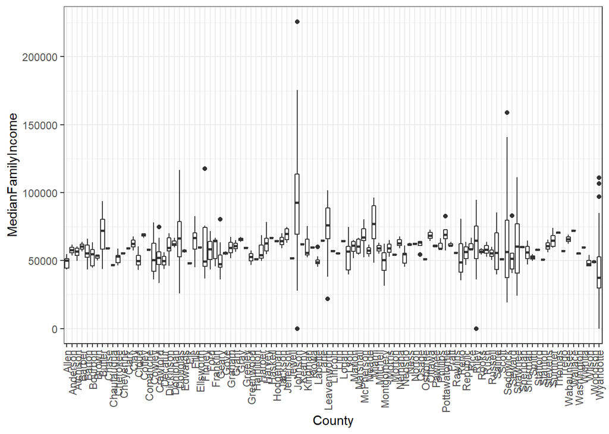

```r
ggplot( foodk, aes(x=County, y=MedianFamilyIncome)) +
  geom_boxplot() +
  theme_bw()+
  theme(axis.text.x = element_text(angle = 90, vjust = 0.5, hjust=1))
```

```r
med.incomeaov <- aov(MedianFamilyIncome ~ County, data=foodk)
summary(med.incomeaov)
```

```
##              Df    Sum Sq   Mean Sq F value   Pr(>F)
## County      104 1.739e+11 1.672e+09   2.892 3.33e-16 ***
## Residuals   665 3.845e+11 5.782e+08
## ---
## Signif. codes:  0 '***' 0.001 '**' 0.01 '*' 0.05 '.' 0.1 ' ' 1
```

```r
vark<-foodk %>%
  group_by(., County) %>%
  summarize(variation = sd(MedianFamilyIncome)) %>%
  arrange(desc(variation))
print(vark)
```

```
## # A tibble: 105 x 2
##    County      variation
##    <chr>           <dbl>
##  1 Johnson        36193.
##  2 Sedgwick       28224.
##  3 Riley          24113.
##  4 Wyandotte      23830.
##  5 Finney         22965.
##  6 Shawnee        22849.
##  7 Leavenworth    21865.
##  8 Douglas        21707.
##  9 Seward         16684.
## 10 Saline         16311.
## # ... with 95 more rows
```

*This plot looks bad, but since we’re supposed to be comparing the median family income across counties and looking at variation I figured this was the best way. There’s too many counties to be able to see the names that well. I didn’t know Kansas has this many counties! There aren’t that many people who live here! Why so many counties?!*

Are there significant differences across counties? Yes, according to an ANOVA test. It would be hard to tell using the figure. Which counties have the greatest variation in income? Johnson county has the greatest variation overall, followed by Sedgwick, then Riley.

### 5. Now check to see how MedianFamilyIncome compares across locations with low (or not) food accessibility (LAhalfand10). Compare using both basic descriptive statistics and graphical representation. What did you find?

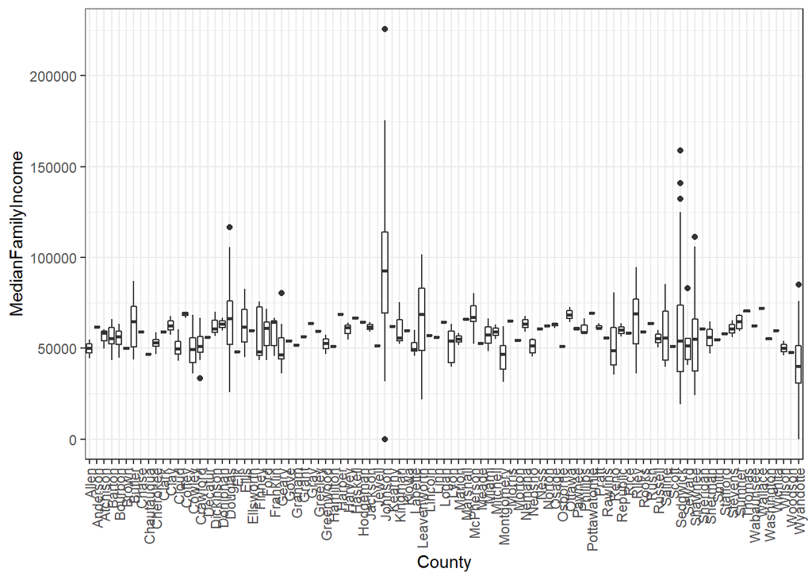

```r
lowaccessk <-foodk %>%
  filter(LAhalfand10 == 1)

ggplot( lowaccessk, aes(x=County, y=MedianFamilyIncome)) +
  geom_boxplot() +
  theme_bw()+
  theme(axis.text.x = element_text(angle = 90, vjust = 0.5, hjust=1))
```

```r
varlowk<-lowaccessk %>%
  group_by(., County) %>%
  summarize(variationinc = sd(MedianFamilyIncome),
            meaninc = mean(MedianFamilyIncome)) %>%
  arrange(desc(variationinc))

print(varlowk)
```

```
## # A tibble: 97 x 3
##    County      variationinc meaninc
##    <chr>              <dbl>   <dbl>
##  1 Johnson           35995.  93928.
##  2 Sedgwick          28695.  60379.
##  3 Leavenworth       24864.  65831.
##  4 Douglas           23282.  68569.
##  5 Shawnee           22989.  55024.
##  6 Riley             17613.  66948.
##  7 Wyandotte         17273.  40273.
##  8 Seward            16684.  54877.
##  9 Saline            16311.  58846.
## 10 Ellis             16028.  62858.
## # ... with 87 more rows
```

```r
med.incomeaov_low <- aov(MedianFamilyIncome ~ County, data=lowaccessk)
summary(med.incomeaov_low)
```

```
##              Df    Sum Sq   Mean Sq F value   Pr(>F)
## County       96 1.624e+11 1.692e+09   2.767 2.77e-13 ***
## Residuals   502 3.070e+11 6.116e+08
## ---
## Signif. codes:  0 '***' 0.001 '**' 0.01 '*' 0.05 '.' 0.1 ' ' 1
```

We can still see that median family income still varies significantly by county, even among counties with low food access.

Johnson county remains the most variable. This is despite the fact that Johnson county also has the largest overall mean family income. This makes sense; there is a lot of inequity in Kansas City.

### 6: Choose one other variable in your Kansas data and examine the variations across counties and food accessibility using both descriptive statistics and graphical comparison. What did you find?

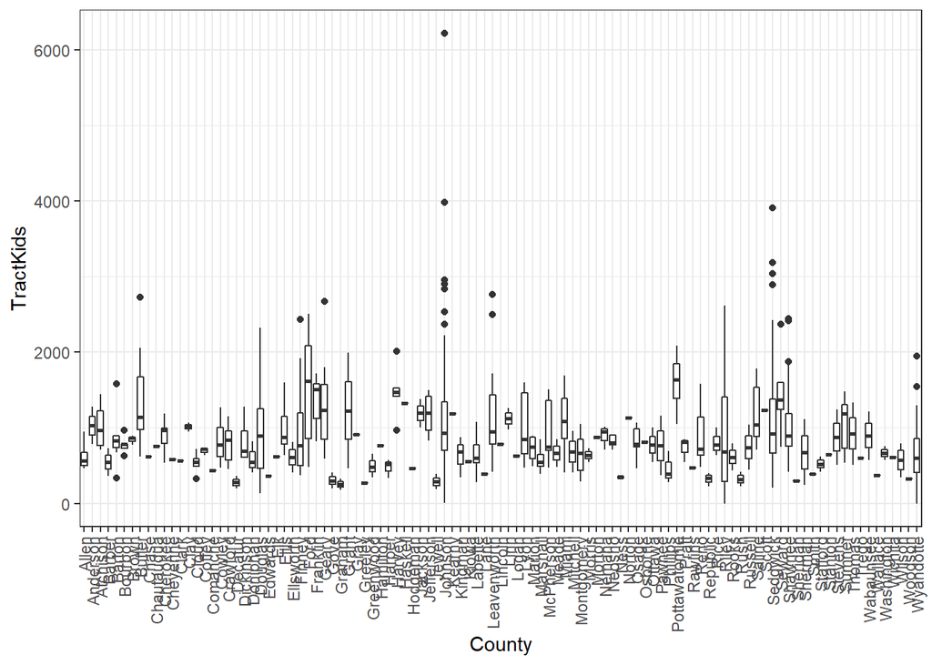

```r
##TractKids

#Across counties

ggplot( foodk, aes(x=County, y=TractKids)) +
  geom_boxplot() +
  theme_bw()+
  theme(axis.text.x = element_text(angle = 90, vjust = 0.5, hjust=1))
```

```r
varKids<-foodk %>%
  group_by(., County) %>%
  summarize(varK = sd(TractKids),
            meanK = mean(TractKids)) %>%
  arrange(desc(meanK))

print(varKids)
```

```
## # A tibble: 105 x 3
##    County        varK meanK
##    <chr>        <dbl> <dbl>
##  1 Pottawatomie  438. 1603.
##  2 Ford          814. 1496.
##  3 Harvey        333. 1476.
##  4 Seward        593. 1467
##  5 Butler        572. 1365.
##  6 Franklin      371. 1350
##  7 Geary         690. 1327.
##  8 Haskell        NA  1326
##  9 Scott          NA  1236
## 10 Grant        1078. 1228.
## # ... with 95 more rows
```

```r
kids.aov <- aov(TractKids ~ County, data=foodk)
summary(kids.aov)
```

```
##              Df    Sum Sq Mean Sq F value   Pr(>F)
## County      104  49649382  477398   1.563 0.000705 ***
## Residuals   665 203121494  305446
## ---
## Signif. codes:  0 '***' 0.001 '**' 0.01 '*' 0.05 '.' 0.1 ' ' 1
```

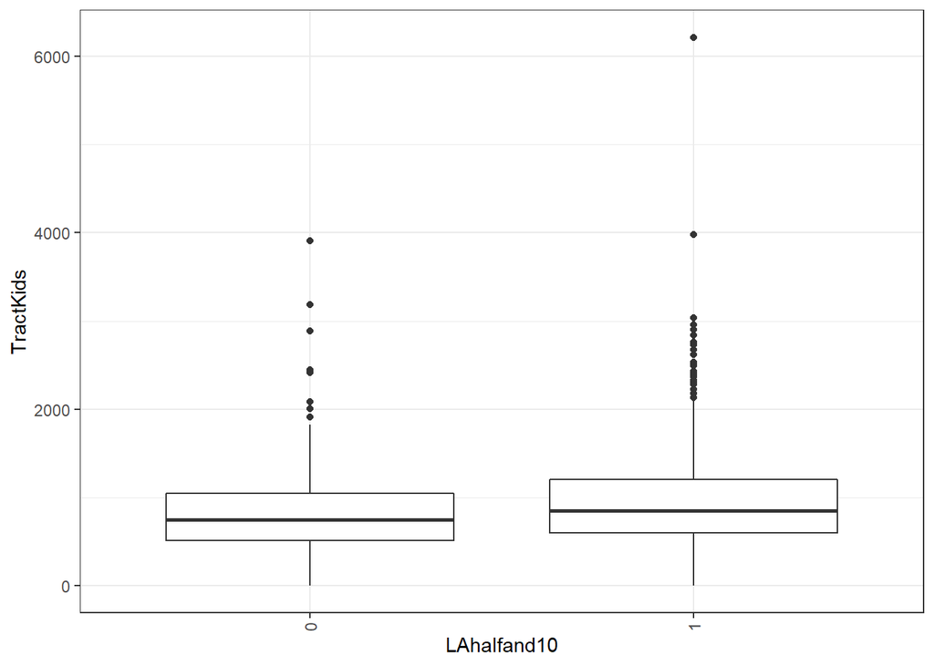

```r
##Food accessible vs not??
foodk$LAhalfand10 <- as.factor(foodk$LAhalfand10)

ggplot( foodk, aes(x=LAhalfand10, y=TractKids)) +
  geom_boxplot() +
  theme_bw()+
  theme(axis.text.x = element_text(angle = 90, vjust = 0.5, hjust=1))
```

```r
varKids_INC<-foodk %>%
  group_by(., LAhalfand10) %>%
  summarize(varK = sd(TractKids),
            meanK = mean(TractKids)) %>%
  arrange(desc(meanK))

print(varKids_INC)
```

```
## # A tibble: 2 x 3
##   LAhalfand10  varK meanK
##   <fct>       <dbl> <dbl>
## 1 1            572.  966.
## 2 0            572.  868.
```

```r
kids_INC <- t.test(TractKids ~ LAhalfand10, data=foodk)
kids_INC
```

```
##
##  Welch Two Sample t-test
##
## data:  TractKids by LAhalfand10
## t = -1.9748, df = 274.85, p-value = 0.04929
## alternative hypothesis: true difference in means between group 0 and group 1 is not equal to 0
## 95 percent confidence interval:
##  -195.5092281   -0.3056095
## sample estimates:
## mean in group 0 mean in group 1
##        867.9123        965.8197
```

Total count of children age 0-17 in tracts varies significantly by county. The highest mean number of kids is in Pottawatomie, followed by Ford, then Harvey.

At first glance, the count of children age 0-17 in tracts does not vary significantly by food accessibility (in the figure). However, if you refer to the t-test you can see there is a significant difference, where places lacking food accessibility have a higher mean number of kids.

### 7: Using either descriptive statistics or graphical comparison (or both) examine how the variables in your Kansas dataset relate to food accessibility and food assistance (SNAP). What variables most explain food accessibility and food assistance? (Show your work please.)

```r
l1<-lm(TractSNAP ~ POP2010, data=foodk)
l2<-lm(TractSNAP ~ LAhalfand10, data=foodk)
l3<-lm(TractSNAP ~ MedianFamilyIncome, data=foodk)
l4<-lm(TractSNAP ~ TractKids, data=foodk)

summary(l1) #Adj. Rsq= 0.05974
```

```
##
## Call:
## lm(formula = TractSNAP ~ POP2010, data = foodk)
##
## Residuals:
##     Min      1Q  Median      3Q     Max
## -275.35  -80.32  -27.45   53.91  510.39
##
## Coefficients:
##              Estimate Std. Error t value Pr(>|t|)
## (Intercept) 80.246695   9.162246   8.758  < 2e-16 ***
## POP2010      0.015626   0.002213   7.061  3.7e-12 ***
## ---
## Signif. codes:  0 '***' 0.001 '**' 0.01 '*' 0.05 '.' 0.1 ' ' 1
##
## Residual standard error: 113.4 on 768 degrees of freedom
## Multiple R-squared:  0.06096,    Adjusted R-squared:  0.05974
## F-statistic: 49.86 on 1 and 768 DF,  p-value: 3.702e-12
```

```r
summary(l2) #Adj. Rsq= = 0.01608
```

```
##
## Call:
## lm(formula = TractSNAP ~ LAhalfand10, data = foodk)
##
## Residuals:
##     Min      1Q  Median      3Q     Max
## -146.38  -86.13  -30.38   54.62  539.62
##
## Coefficients:
##              Estimate Std. Error t value Pr(>|t|)
## (Intercept)   109.316      8.874  12.319  < 2e-16 ***
## LAhalfand101   37.060     10.061   3.683 0.000246 ***
## ---
## Signif. codes:  0 '***' 0.001 '**' 0.01 '*' 0.05 '.' 0.1 ' ' 1
##
## Residual standard error: 116 on 768 degrees of freedom
## Multiple R-squared:  0.01736,    Adjusted R-squared:  0.01608
## F-statistic: 13.57 on 1 and 768 DF,  p-value: 0.0002463
```

```r
summary(l3) #Adj. Rsq=.2424
```

```
##
## Call:
## lm(formula = TractSNAP ~ MedianFamilyIncome, data = foodk)
##
## Residuals:
##     Min      1Q  Median      3Q     Max
## -274.56  -67.33  -20.23   47.69  507.48
##
## Coefficients:
##                      Estimate Std. Error t value Pr(>|t|)
## (Intercept)         2.746e+02  9.423e+00   29.14   <2e-16 ***
## MedianFamilyIncome -2.142e-03  1.363e-04  -15.72   <2e-16 ***
## ---
## Signif. codes:  0 '***' 0.001 '**' 0.01 '*' 0.05 '.' 0.1 ' ' 1
##
## Residual standard error: 101.8 on 768 degrees of freedom
## Multiple R-squared:  0.2434, Adjusted R-squared:  0.2424
## F-statistic:   247 on 1 and 768 DF,  p-value: < 2.2e-16
```

```r
summary(l4) #Adj. Rsq= 0.06076
```

```
##
## Call:
## lm(formula = TractSNAP ~ TractKids, data = foodk)
##
## Residuals:
##     Min      1Q  Median      3Q     Max
## -338.97  -79.57  -26.09   53.30  500.61
##
## Coefficients:
##              Estimate Std. Error t value Pr(>|t|)
## (Intercept) 90.184727   7.875233  11.452  < 2e-16 ***
## TractKids    0.050802   0.007131   7.124 2.42e-12 ***
## ---
## Signif. codes:  0 '***' 0.001 '**' 0.01 '*' 0.05 '.' 0.1 ' ' 1
##
## Residual standard error: 113.4 on 768 degrees of freedom
## Multiple R-squared:  0.06198,    Adjusted R-squared:  0.06076
## F-statistic: 50.75 on 1 and 768 DF,  p-value: 2.418e-12
```

According to linear models, MedianFamilyIncome explains the most variation in TractSnap.This is because the linear model of TractSnap ~ MedianFamilyIncome has the highest adjusted R-squared value (0.2424).

### 8: Use the full national dataset you created in step 1 and create a state-by-state summary of each variable. Use this state summary dataset to examine how food accessibility varies across states (you can choose which measure of food accessibility to use). Which states have the most problems with food accessibility? Which have the lowest?

```r
summarized<-foodr %>%
  select(-County) %>%
  group_by(State) %>%
  summarise(across(everything(), list(MEAN = mean, VAR=sd))) %>%
  arrange(desc(LA1and10_MEAN))

head(summarized, 20) #state by state mean of all variables, including mean and variation
```

```
## # A tibble: 20 x 69
##    State      CensusTract_MEAN CensusTract_VAR Urban_MEAN Urban_VAR POP2010_MEAN
##    <chr>                 <dbl>           <dbl>      <dbl>     <dbl>        <dbl>
##  1 South Dak~     46074722279.       37252572.      0.423     0.495        3667.
##  2 Wyoming        56022010579.       12204804.      0.523     0.501        4270.
##  3 North Dak~     38051211640.       34079723.      0.424     0.495        3281.
##  4 New Mexico     35023716506.       20716034.      0.689     0.463        4127.
##  5 Alaska          2105042435.       78590267.      0.509     0.501        4253.
##  6 Idaho          16033597818.       27718384.      0.570     0.496        5260.
##  7 Mississip~     28076474568.       42254661.      0.497     0.500        4482.
##  8 Montana        30055274136.       34173722.      0.406     0.492        3651.
##  9 Georgia        13132604567.       78815975.      0.671     0.470        4930.
## 10 Arkansas        5078835064.       46110947.      0.488     0.500        4251.
## 11 Kansas         20122002030.       59611060.      0.660     0.474        3705.
## 12 Connectic~      9005855743.        4232563.      0.849     0.359        4296.
## 13 Texas          48228086637.      146524138.      0.779     0.415        4782.
## 14 Minnesota      27079463388.       49819985.      0.679     0.467        3970.
## 15 Missouri       29147667652.      119916419.      0.668     0.471        4299.
## 16 South Car~     45049074841.       26740004.      0.594     0.491        4193.
## 17 Nebraska       31087969718.       46793279.      0.656     0.475        3433.
## 18 Utah           49036289190.       15354437.      0.847     0.360        4700.
## 19 Oklahoma       40094247482.       44424289.      0.644     0.479        3586.
## 20 Tennessee      47101972553.       55954985.      0.599     0.490        4239.
## # ... with 63 more variables: POP2010_VAR <dbl>, OHU2010_MEAN <dbl>,
## #   OHU2010_VAR <dbl>, GroupQuartersFlag_MEAN <dbl>,
## #   GroupQuartersFlag_VAR <dbl>, NUMGQTRS_MEAN <dbl>, NUMGQTRS_VAR <dbl>,
## #   PCTGQTRS_MEAN <dbl>, PCTGQTRS_VAR <dbl>, LILATracts_1And10_MEAN <dbl>,
## #   LILATracts_1And10_VAR <dbl>, LILATracts_halfAnd10_MEAN <dbl>,
## #   LILATracts_halfAnd10_VAR <dbl>, LILATracts_1And20_MEAN <dbl>,
## #   LILATracts_1And20_VAR <dbl>, LILATracts_Vehicle_MEAN <dbl>, ...
```

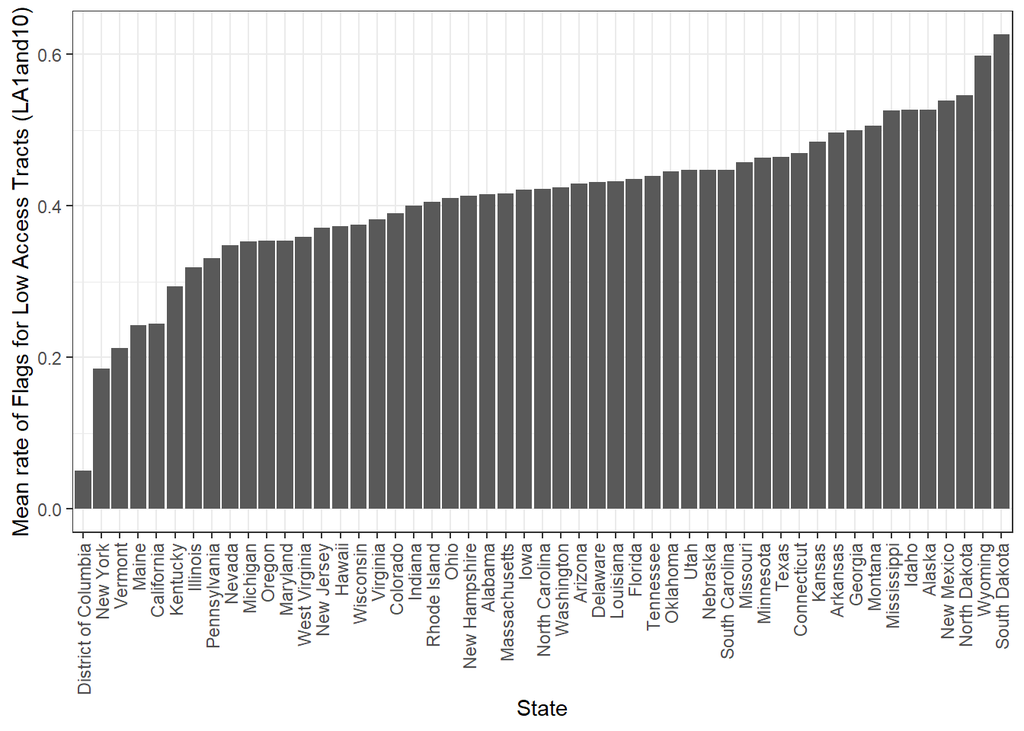

```r
ggplot(summarized, aes(x= reorder(State, LA1and10_MEAN), y= LA1and10_MEAN  ))+
  geom_bar(stat = 'identity')+
  theme_bw()+
  theme(axis.text.x = element_text(angle = 90, vjust = 0.5, hjust=1)) +
  ylab("Mean rate of Flags for Low Access Tracts (LA1and10)") +
  xlab("State")
```

Which states have the most problems with food accessibility?

*on average, it looks like South Dakota, Wyoming, North Dakota, and New Mexico have the greatest problems for food accessibility, with the highest overall mean rate at which “flags for low access tracts” (LA1and10) appear.*

Which have the lowest?

*on average, it looks like Washington DC, New York, and Vermont have the least problems for food accessibility, with the lowest overall mean rate at which “flags for low access tracts” (LA1and10) appear.*

### 9: Examine the trends between 3 variables of your choice and food accessibility across states in the US and describe your findings.

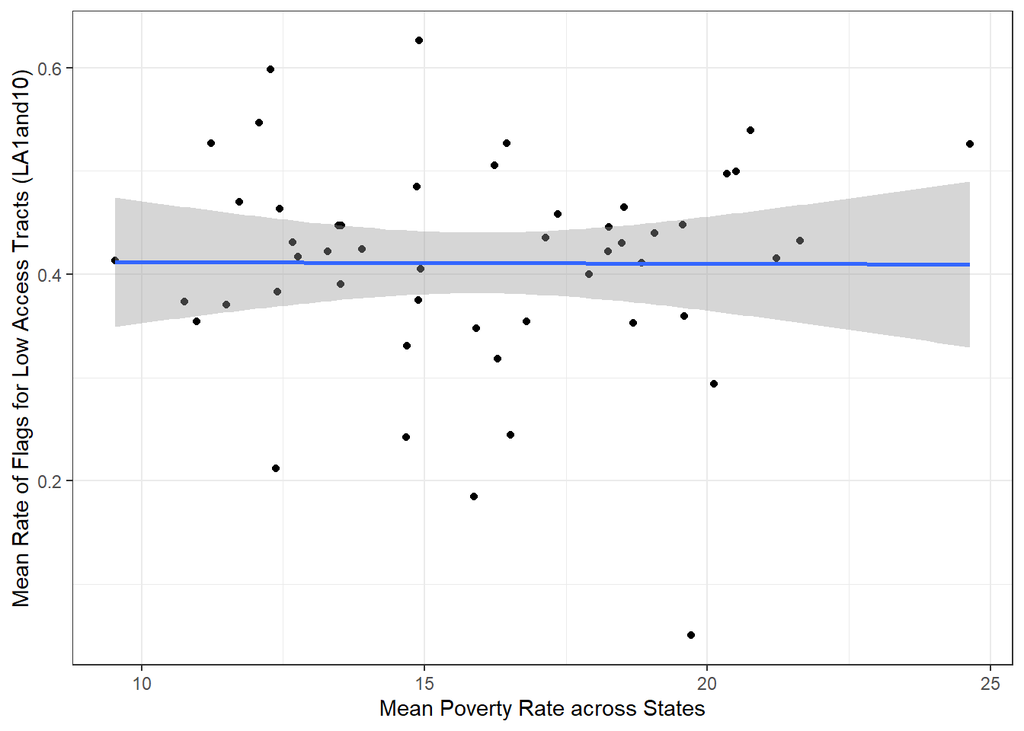

```r
#Food accessibility vs PovertyRate (Share of the tract population living with income at or below the Federal poverty thresholds for family size)

ggplot(summarized, aes(x=PovertyRate_MEAN, y= LA1and10_MEAN)) +
  geom_point()+
  geom_smooth(method="lm")+
  theme_bw()+
  ylab("Mean Rate of Flags for Low Access Tracts (LA1and10)") +
  xlab("Mean Poverty Rate across States")
```

```r
lm_pov<- lm(LA1and10_MEAN~PovertyRate_MEAN, summarized)
summary(lm_pov)
```

```
##
## Call:
## lm(formula = LA1and10_MEAN ~ PovertyRate_MEAN, data = summarized)
##
## Residuals:
##      Min       1Q   Median       3Q      Max
## -0.36008 -0.04587  0.01141  0.05318  0.21505
##
## Coefficients:
##                    Estimate Std. Error t value Pr(>|t|)
## (Intercept)       0.4132787  0.0699924   5.905 3.28e-07 ***
## PovertyRate_MEAN -0.0001481  0.0042879  -0.035    0.973
## ---
## Signif. codes:  0 '***' 0.001 '**' 0.01 '*' 0.05 '.' 0.1 ' ' 1
##
## Residual standard error: 0.1043 on 49 degrees of freedom
## Multiple R-squared:  2.433e-05,  Adjusted R-squared:  -0.02038
## F-statistic: 0.001192 on 1 and 49 DF,  p-value: 0.9726
```

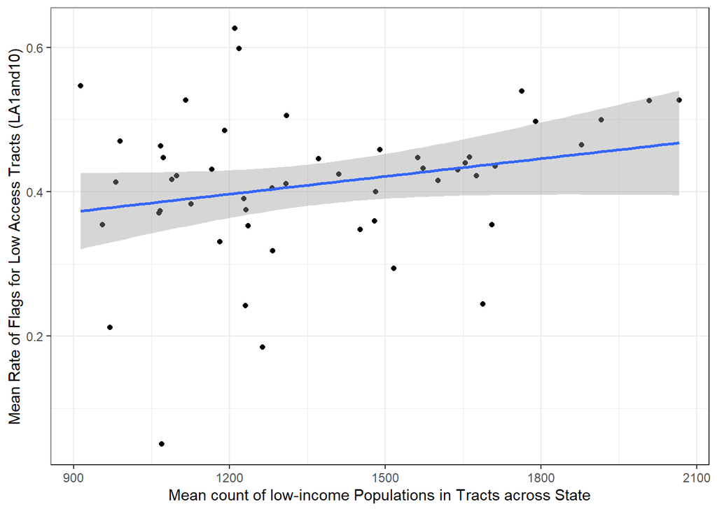

```r
#Food accessibility vs TractLOWI (Total count of low-income population in tract )
ggplot(summarized, aes(x=TractLOWI_MEAN, y= LA1and10_MEAN)) +
  geom_point()+
  geom_smooth(method="lm")+
  theme_bw()+
  ylab("Mean Rate of Flags for Low Access Tracts (LA1and10)") +
  xlab("Mean count of low-income Populations in Tracts across State")
```

```r
lm_LOWI<- lm(LA1and10_MEAN~TractLOWI_MEAN, summarized)
summary(lm_LOWI)
```

```
##
## Call:
## lm(formula = LA1and10_MEAN ~ TractLOWI_MEAN, data = summarized)
##
## Residuals:
##      Min       1Q   Median       3Q      Max
## -0.33582 -0.02334  0.00494  0.04820  0.22854
##
## Coefficients:
##                 Estimate Std. Error t value Pr(>|t|)
## (Intercept)    2.986e-01  6.723e-02   4.441 5.09e-05 ***
## TractLOWI_MEAN 8.184e-05  4.788e-05   1.709   0.0937 .
## ---
## Signif. codes:  0 '***' 0.001 '**' 0.01 '*' 0.05 '.' 0.1 ' ' 1
##
## Residual standard error: 0.1013 on 49 degrees of freedom
## Multiple R-squared:  0.05627,    Adjusted R-squared:  0.03701
## F-statistic: 2.922 on 1 and 49 DF,  p-value: 0.09373
```

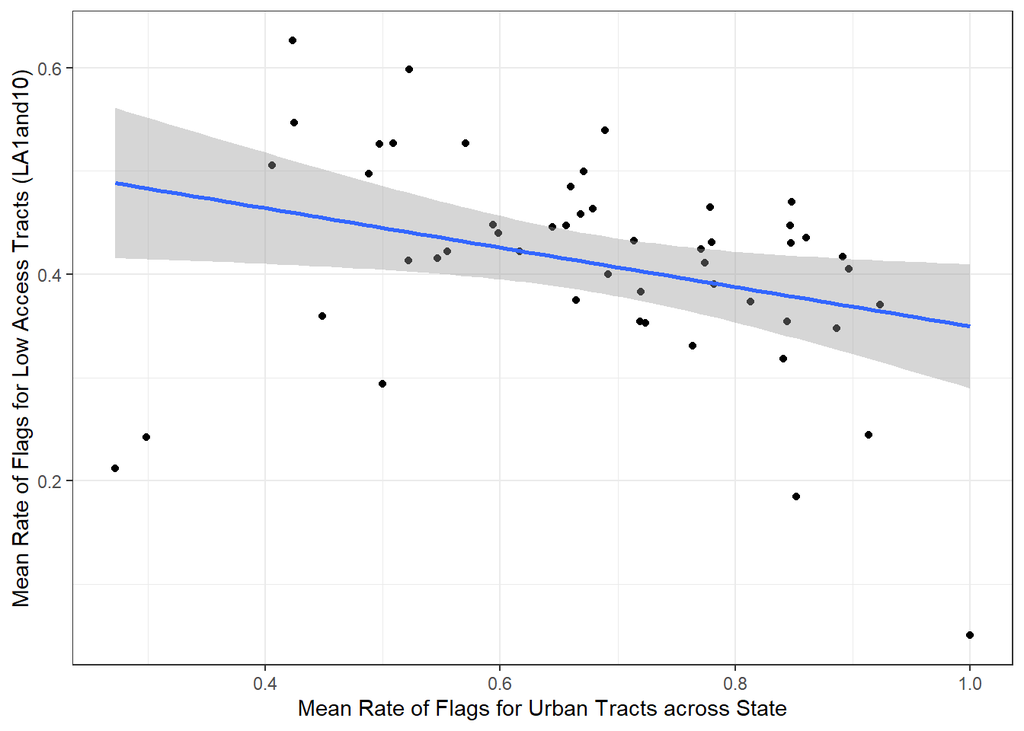

```r
#Food accessibility vs Urban (Flag for urban tract)

ggplot(summarized, aes(x=Urban_MEAN, y= LA1and10_MEAN)) +
  geom_point()+
  geom_smooth(method="lm")+
  theme_bw()+
  ylab("Mean Rate of Flags for Low Access Tracts (LA1and10)") +
  xlab("Mean Rate of Flags for Urban Tracts across State")
```

```r
lm_urb<- lm(LA1and10_MEAN~Urban_MEAN, summarized)
summary(lm_urb)
```

```
##
## Call:
## lm(formula = LA1and10_MEAN ~ Urban_MEAN, data = summarized)
##
## Residuals:
##      Min       1Q   Median       3Q      Max
## -0.29943 -0.02601  0.02081  0.05560  0.16661
##
## Coefficients:
##             Estimate Std. Error t value Pr(>|t|)
## (Intercept)  0.54015    0.05753   9.389 1.56e-12 ***
## Urban_MEAN  -0.19045    0.08228  -2.315   0.0249 *
## ---
## Signif. codes:  0 '***' 0.001 '**' 0.01 '*' 0.05 '.' 0.1 ' ' 1
##
## Residual standard error: 0.09904 on 49 degrees of freedom
## Multiple R-squared:  0.09857,    Adjusted R-squared:  0.08017
## F-statistic: 5.358 on 1 and 49 DF,  p-value: 0.02486
```